### Title: Practical Machine Learning - Final Project

–Author: Viet Nguyen –Date: August 13, 2016

## Overview

Using devices such as Jawbone Up, Nike FuelBand, and Fitbit it is now possible to collect a large amount of data about personal activity relatively inexpensively. These type of devices are part of the quantified self movement - a group of enthusiasts who take measurements about themselves regularly to improve their health, to find patterns in their behavior, or because they are tech geeks. One thing that people regularly do is quantify how much of a particular activity they do, but they rarely quantify how well they do it. In this project, your goal will be to use data from accelerometers on the belt, forearm, arm, and dumbell of 6 participants. They were asked to perform barbell lifts correctly and incorrectly in 5 different ways. More information is available from the website here: http://groupware.les.inf.puc-rio.br/har (see the section on the Weight Lifting Exercise Dataset).

## Preparation step: Data andlibraries loading

- Working Directory and load data

```r
setwd("C:/Users/user/Desktop/RWD/PML")
set.seed(12345)

library(knitr)
library(caret)
```

```r
library(rpart)
library(rpart.plot)
library(rattle)
library(randomForest)
library(corrplot)
trainUrl <- "http://d396qusza40orc.cloudfront.net/predmachlearn/pml-training.csv"
testUrl <- "http://d396qusza40orc.cloudfront.net/predmachlearn/pml-testing.csv"

training <- read.csv(url(trainUrl))
testing <- read.csv(url(testUrl))
```

- Partioning the training set

```r
library(caret)
inTrain <- createDataPartition(training$classe, p=0.6, list=FALSE)
Training <- training[inTrain,]
Testing <- training[-inTrain,]
dim(Training); dim(Testing)
```

```
## [1] 11776   160
```

```
## [1] 7846  160
```

## Cleaning the data

- Remove NearZeroVariance variables

```r
NZV <- nearZeroVar(Training)
Training <- Training[, -NZV]
Testing  <- Testing[, -NZV]
dim(Training); dim(Testing)
```

```
## [1] 11776   108
```

```
## [1] 7846  108
```

- Remove NA variables

```r
AllNA    <- sapply(Training, function(x) mean(is.na(x))) > 0.95
Training <- Training[, AllNA==FALSE]
Testing  <- Testing[, AllNA==FALSE]
dim(Training); dim(Testing)
```

```
## [1] 11776    59
```

```
## [1] 7846   59
```

- Rmove identification only variables (columns 1 to 5)

```r
Training <- Training[, -(1:5)]
Testing  <- Testing[, -(1:5)]
dim(Training); dim(Testing)
```

```
## [1] 11776    54
```

```
## [1] 7846   54
```

### Prediction Model Building

Three prediction model methods - Random Forests, Decision Tree and Generalized Boosted Model - will be applied for the Training dataset, then the best one with highest accuracy when applied to the Test dataset would be used for the quiz predictions.

## 1.Decision Trees

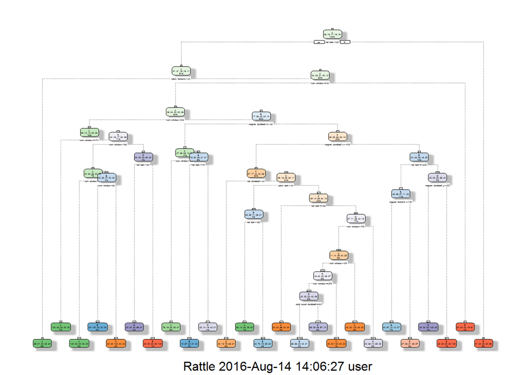

```r
set.seed(12345)
DecTree <- rpart(classe ~ ., data=Training, method="class")
fancyRpartPlot(DecTree)
```

-Applied it to Testing Set

```r
predictDecTree <- predict(DecTree, newdata=Testing, type="class")
confMatDecTree <- confusionMatrix(predictDecTree, Testing$classe)
confMatDecTree
```

```
## Confusion Matrix and Statistics
##
##           Reference
## Prediction    A    B    C    D    E
##          A 1969  111    3   28   11
##          B  136 1169   86   90   67
##          C    1   77 1138   45    6
##          D  101   93  138 1047  234
##          E   25   68    3   76 1124
##
## Overall Statistics
##
##                Accuracy : 0.8217
##                  95% CI : (0.813, 0.8301)
##     No Information Rate : 0.2845
##     P-Value [Acc > NIR] : < 2.2e-16
##
##                   Kappa : 0.7751
##  Mcnemar's Test P-Value : < 2.2e-16
##
## Statistics by Class:
##
##                      Class: A Class: B Class: C Class: D Class: E
## Sensitivity            0.8822   0.7701   0.8319   0.8142   0.7795
## Specificity            0.9727   0.9401   0.9801   0.9137   0.9731
## Pos Pred Value         0.9279   0.7552   0.8982   0.6491   0.8673
## Neg Pred Value         0.9541   0.9446   0.9650   0.9617   0.9515
## Prevalence             0.2845   0.1935   0.1744   0.1639   0.1838
## Detection Rate         0.2510   0.1490   0.1450   0.1334   0.1433
## Detection Prevalence   0.2705   0.1973   0.1615   0.2056   0.1652
## Balanced Accuracy      0.9275   0.8551   0.9060   0.8639   0.8763
```

– Plot the results

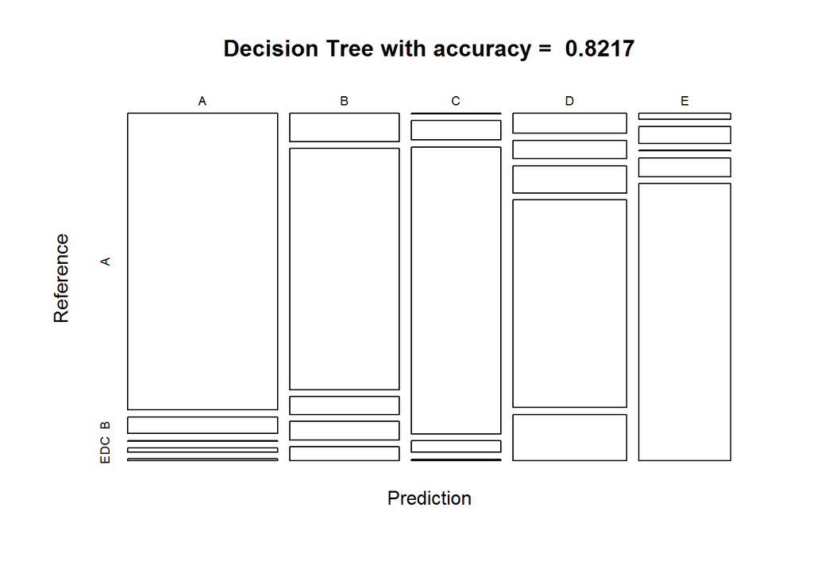

```r
plot(confMatDecTree$table, col = confMatDecTree$byClass, main = paste("Decision Tree with accuracy = ",round(confMatDecTree$overall['Accuracy'], 4)))
```

## 2.Random Forest

```r
set.seed(12345)
RF <- trainControl(method="cv", number=3, verboseIter=FALSE)
modFitRandForest <- train(classe ~ ., data=Training, method="rf",trControl=RF)
modFitRandForest$finalModel
```

```
##
## Call:
##  randomForest(x = x, y = y, mtry = param$mtry)
##                Type of random forest: classification
##                      Number of trees: 500
## No. of variables tried at each split: 27
##
##         OOB estimate of  error rate: 0.33%
## Confusion matrix:
##      A    B    C    D    E  class.error
## A 3347    1    0    0    0 0.0002986858
## B    8 2267    4    0    0 0.0052654673
## C    0    6 2047    1    0 0.0034079844
## D    0    0   10 1919    1 0.0056994819
## E    0    1    1    6 2157 0.0036951501
```

– Applied it to testing set

```r
predictRandForest <- predict(modFitRandForest, newdata=Testing)
confMatRandForest <- confusionMatrix(predictRandForest, Testing$classe)
confMatRandForest
```

```
## Confusion Matrix and Statistics
##
##           Reference
## Prediction    A    B    C    D    E
##          A 2231    3    0    0    0
##          B    0 1510    6    0    2
##          C    0    5 1362    4    0
##          D    0    0    0 1281    2
##          E    1    0    0    1 1438
##
## Overall Statistics
##
##                Accuracy : 0.9969
##                  95% CI : (0.9955, 0.998)
##     No Information Rate : 0.2845
##     P-Value [Acc > NIR] : < 2.2e-16
##
##                   Kappa : 0.9961
##  Mcnemar's Test P-Value : NA
##
## Statistics by Class:
##
##                      Class: A Class: B Class: C Class: D Class: E
## Sensitivity            0.9996   0.9947   0.9956   0.9961   0.9972
## Specificity            0.9995   0.9987   0.9986   0.9997   0.9997
## Pos Pred Value         0.9987   0.9947   0.9934   0.9984   0.9986
## Neg Pred Value         0.9998   0.9987   0.9991   0.9992   0.9994
## Prevalence             0.2845   0.1935   0.1744   0.1639   0.1838
## Detection Rate         0.2843   0.1925   0.1736   0.1633   0.1833
## Detection Prevalence   0.2847   0.1935   0.1747   0.1635   0.1835
## Balanced Accuracy      0.9995   0.9967   0.9971   0.9979   0.9985
```

– Plot the results

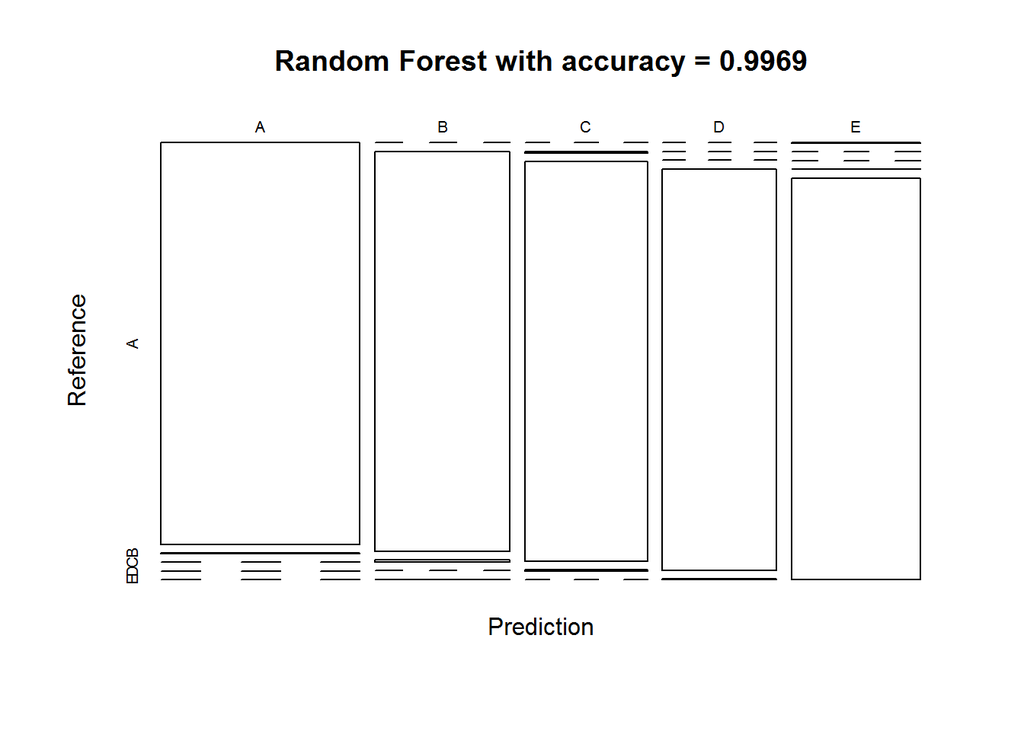

```r
plot(confMatRandForest$table, col = confMatRandForest$byClass, main = paste("Random Forest with accuracy =", round(confMatRandForest$overall['Accuracy'], 4)))
```

### 3.Generalized Boosted Model

```r
set.seed(12345)
GBM <- trainControl(method = "repeatedcv", number = 5, repeats = 1)

modFitGBM  <- train(classe ~ ., data=Training, method = "gbm", trControl = GBM, verbose = FALSE)
modFitGBM$finalModel
```

```
## A gradient boosted model with multinomial loss function.
## 150 iterations were performed.
## There were 53 predictors of which 45 had non-zero influence.
```

– Applied it to Testing Set

```r
predictGBM <- predict(modFitGBM, newdata=Testing)
confMatGBM <- confusionMatrix(predictGBM, Testing$classe)
confMatGBM
```

```
## Confusion Matrix and Statistics
##
##           Reference
## Prediction    A    B    C    D    E
##          A 2229   15    0    2    0
##          B    1 1478   13    8    5
##          C    0   24 1352   18    3
##          D    1    1    3 1256    7
##          E    1    0    0    2 1427
##
## Overall Statistics
##
##                Accuracy : 0.9867
##                  95% CI : (0.984, 0.9892)
##     No Information Rate : 0.2845
##     P-Value [Acc > NIR] : < 2.2e-16
##
##                   Kappa : 0.9832
##  Mcnemar's Test P-Value : NA
##
## Statistics by Class:
##
##                      Class: A Class: B Class: C Class: D Class: E
## Sensitivity            0.9987   0.9736   0.9883   0.9767   0.9896
## Specificity            0.9970   0.9957   0.9931   0.9982   0.9995
## Pos Pred Value         0.9924   0.9821   0.9678   0.9905   0.9979
## Neg Pred Value         0.9995   0.9937   0.9975   0.9954   0.9977
## Prevalence             0.2845   0.1935   0.1744   0.1639   0.1838
## Detection Rate         0.2841   0.1884   0.1723   0.1601   0.1819
## Detection Prevalence   0.2863   0.1918   0.1781   0.1616   0.1823
## Balanced Accuracy      0.9978   0.9847   0.9907   0.9874   0.9946
```

– Plot the results

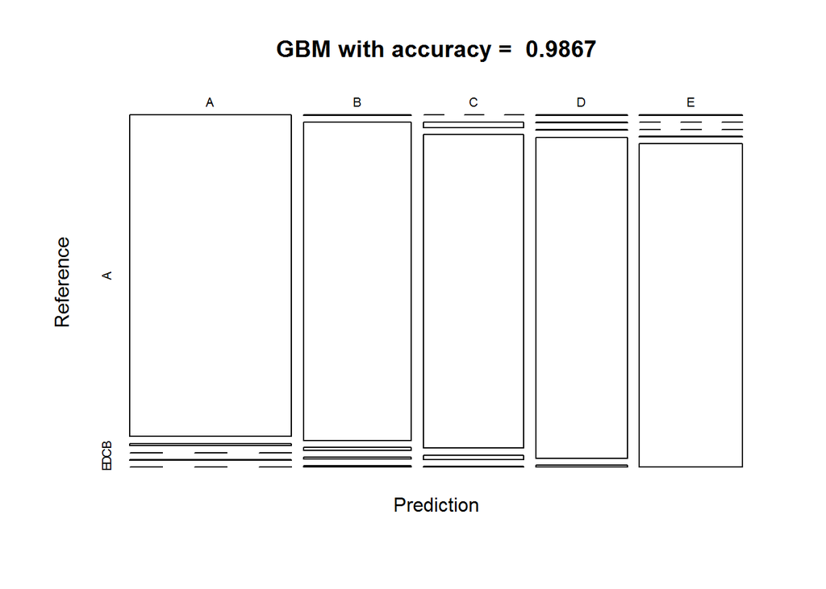

```r
plot(confMatGBM$table, col = confMatGBM$byClass, main = paste("GBM with accuracy = ", round(confMatGBM$overall['Accuracy'], 4)))
```

### Results and apply the models to the quiz

Random Forest is the best among these. It is applied to predict 20 cases in the quiz:

```r
predictTEST <- predict(modFitRandForest, newdata=testing)
predictTEST
```

```
##  [1] B A B A A E D B A A B C B A E E A B B B
## Levels: A B C D E
```